# Estudios de Informática, Multimedia y Telecomunicaciones

# Práctica 2: Limpieza y análisis de datos

Cristina Merino García de la Reina, Isabel González Valle

6 de junio, 2020

**Descripción**

**El objetivo de esta actividad será el tratamiento de un dataset, que puede ser el creado en la práctica 1 o bien cualquier dataset libre disponible en Kaggle (https://www.kaggle.com).**

**Siguiendo las principales etapas de un proyecto analítico, las diferentes tareas a realizar (y justificar) son las siguientes:**

# **1. Descripción del dataset**

**¿Por qué es importante y qué pregunta/problema pretende responder?**

Para esta práctica hemos buscado un dataset de los vuelos que fueron cancelados o que sufrieron retrasos en durante el año 2015 comunicados a través del Departamento de Estadísticas de Transportes de los Estados Unidos. Este conjunto de datos contiene la información correspondiente a los vuelos operados por las grandes compañías aéreas.  
Poder conocer y tener una referencia del motivo de los vuelos cancelados o retrasados es interesante para las personas que deben usar este medio de transporte. Se pueden analizar diferentes problemáticas, como la relación entre los vuelos retrasados y los días de la semana, así como identificar cuál puede ser el mejor mes para viajar, que aeropuerto debemos evitar y por último, buscaremos identificar cuál es la mejor compañía para viajar. Intentaremos dar respuesta a algunas de estas preguntas durante esta práctica.  
https://www.kaggle.com/usdot/flight-delays  
El tipo de licencia de este dataset es: *CC0 1.0 Universal (CC0 1.0) Public Domain Dedication* . Por lo tanto es público y puede ser utilizado libremente para el trabajo que vamos a realizar.  
El conjunto de datos elegido contiene 31 variables y casi 6 millones de observaciones, por lo que de cara a la práctica reduciremos la cantidad de datos, intentando que la muestra a utilizar represente el conjunto de datos original lo más fielmente posible, para ello utilizaremos las técnicas de muestreo que se estudiaron en el módulo anterior.  
Del mismo modo, eliminaremos aquellas variables que no aporten valor al estudio que vamos a realizar, reduciendo así la dimensionalidad del conjunto de datos.  
En cuanto a las variables del dataset, se tienen las siguientes:  
* YEAR: Año del vuelo (2015)  
* MONTH: Mes del vuelo  
* DAY: Día del vuelo  
* DAY_OF_WEEK: Día de la semana, donde el día 1=lunes y el 7=Domingo  
* AIRLINE: Código de la aerolínea  
* FLIGHT_NUMBER: Número de vuelo  
* TAIL_NUMBER: Número de identificación de la aeronave  
* ORIGIN_AIRPORT: Aeropuerto Origen  
* DESTINATION_AIRPORT: Aeropuerto Destino  
* SCHEDULED_DEPARTURE: Hora programada de salida en formato hhmm (55 -> 00:55)  
* DEPARTURE_TIME: Hora de salida del vuelo en formato hhmm  
* DEPARTURE_DELAY: Diferencia en minutos entre la salida programada y la real ( valores negativos identifican salidas del vuelo con antelaión)  
* TAXI_OUT: Tiempo de rodaje del avión desde que deja la puerta de embarque hasta despegue.  
* WHEELS_OFF: Hora en la que el avión despega, momento en el que las ruedas del avión dejan de tocar el suelo  
* SCHEDULED_TIME: Tiempo programado de vuelo.  
* ELAPSED_TIME: Tiempo total de vuelo contado desde el momento que el avión se pone en marcha hasta que para completamente en destino, es decir contando el rodaje en el aeropuerto.  
* AIR_TIME: Tiempo desde despegue hasta aterrizaje  
* DISTANCE: Distancia en millas  
* WHEELS_ON: Hora en la que el avión toca tierra.  
* TAXI_IN: Tiempo de rodaje en el aeropuerto destino hasta que el avión para completamente.  
* SCHEDULED_ARRIVAL: Hora programada de llegada en formato hhmm  
* ARRIVAL_TIME: Hora de llegada real en formato hhmm  
* ARRIVAL_DELAY: Diferencia en minutos entre la salida programada y la real  
* DIVERTED: Vuelo desviado (0-No, 1-Sí) * CANCELLED: Vuelo Cancelado (0-No, 1-Sí) * CANCELLATION_REASON: Motivo de cancelación (A-Carrier, B-Weather, C-National Air System, D-Security) * AIR_SYSTEM_DELAY: Tiempo de retraso por el motivo indicado  
* SECURITY_DELAY: Tiempo de retraso por el motivo indicado  
* AIRLINE_DELAY: Tiempo de retraso por el motivo indicado  
* LATE_AIRCRAFT_DELAY: Tiempo de retraso por el motivo indicado  
* WEATHER_DELAY: Tiempo de retraso por el motivo indicado

```r
#Cargamos el dataset
vuelos <- read.csv("flights.csv", sep=c(","), header = TRUE)

head(vuelos)
```

```
##   YEAR MONTH DAY DAY_OF_WEEK AIRLINE FLIGHT_NUMBER TAIL_NUMBER ORIGIN_AIRPORT
## 1 2015     1   1           4      AS            98      N407AS            ANC
## 2 2015     1   1           4      AA          2336      N3KUAA            LAX
## 3 2015     1   1           4      US           840      N171US            SFO
## 4 2015     1   1           4      AA           258      N3HYAA            LAX
## 5 2015     1   1           4      AS           135      N527AS            SEA
## 6 2015     1   1           4      DL           806      N3730B            SFO
##   DESTINATION_AIRPORT SCHEDULED_DEPARTURE DEPARTURE_TIME DEPARTURE_DELAY
## 1                 SEA                   5           2354             -11
## 2                 PBI                  10              2              -8
## 3                 CLT                  20             18              -2
## 4                 MIA                  20             15              -5
## 5                 ANC                  25             24              -1
## 6                 MSP                  25             20              -5
##   TAXI_OUT WHEELS_OFF SCHEDULED_TIME ELAPSED_TIME AIR_TIME DISTANCE WHEELS_ON
```

[output cut: 27 more lines]

Este conjunto de datos tiene un tamaño demasiado grande para algunas de las operaciones que necesitamos hacer y por este motivo hemos decidido realizar la práctica con un subconjunto del mismo. En el caso necesario, todos los cálculos se podrían repetir con el conjunto completo.

```r
#Reducción de la cantidad
set.seed(222)
index <- sample(1:nrow(vuelos), size=0.05*nrow(vuelos))
vuelos_reduc <- vuelos[index,]
str(vuelos_reduc)
```

```
## 'data.frame':    290953 obs. of  31 variables:
##  $ YEAR               : int  2015 2015 2015 2015 2015 2015 2015 2015 2015 2015 ...
##  $ MONTH              : int  11 4 4 7 2 7 12 2 3 2 ...
##  $ DAY                : int  16 7 1 28 9 23 24 22 8 8 ...
##  $ DAY_OF_WEEK        : int  1 2 3 2 1 4 4 7 7 7 ...
##  $ AIRLINE            : Factor w/ 14 levels "AA","AS","B6",..: 5 14 4 5 14 1 14 10 8 4 ...
##  $ FLIGHT_NUMBER      : int  5084 1023 2182 4330 1963 2148 1915 4636 2950 2104 ...
##  $ TAIL_NUMBER        : Factor w/ 4898 levels "","7819A","7820L",..: 3370 3505 4730 149 3706 4748 1306 1795 4640 4580 ...
##  $ ORIGIN_AIRPORT     : Factor w/ 628 levels "10135","10136",..: 327 358 439 504 483 346 344 593 535 523 ...
##  $ DESTINATION_AIRPORT: Factor w/ 629 levels "10135","10136",..: 614 577 328 459 500 490 368 432 573 393 ...
##  $ SCHEDULED_DEPARTURE: int  825 930 540 1545 1055 600 1125 1956 1145 1935 ...
##  $ DEPARTURE_TIME     : int  819 943 538 1559 1105 553 1124 2002 1242 1932 ...
##  $ DEPARTURE_DELAY    : int  -6 13 -2 14 10 -7 -1 6 57 -3 ...
##  $ TAXI_OUT           : int  14 10 12 21 7 15 18 18 15 37 ...
##  $ WHEELS_OFF         : int  833 953 550 1620 1112 608 1142 2020 1257 2009 ...
```

[output cut: 17 more lines]

Hemos visto los primeros valores que toman las variables del conjunto con los datos reducidos. Ahora veremos un pequeño resumen estadístico de dichas variables.

```r
summary(vuelos_reduc)
```

```
##       YEAR          MONTH            DAY         DAY_OF_WEEK       AIRLINE
##  Min.   :2015   Min.   : 1.00   Min.   : 1.00   Min.   :1.000   WN     :63169
##  1st Qu.:2015   1st Qu.: 4.00   1st Qu.: 8.00   1st Qu.:2.000   DL     :43650
##  Median :2015   Median : 7.00   Median :16.00   Median :4.000   AA     :36347
##  Mean   :2015   Mean   : 6.53   Mean   :15.72   Mean   :3.925   OO     :29373
##  3rd Qu.:2015   3rd Qu.: 9.00   3rd Qu.:23.00   3rd Qu.:6.000   EV     :28617
##  Max.   :2015   Max.   :12.00   Max.   :31.00   Max.   :7.000   UA     :25893
##                                                                 (Other):63904
##  FLIGHT_NUMBER   TAIL_NUMBER     ORIGIN_AIRPORT   DESTINATION_AIRPORT
##  Min.   :   1          :   709   ATL    : 17374   ATL    : 17274
##  1st Qu.: 732   N480HA :   193   ORD    : 14214   ORD    : 13989
##  Median :1688   N486HA :   193   DFW    : 11971   DFW    : 12169
##  Mean   :2170   N478HA :   185   DEN    :  9663   LAX    :  9823
##  3rd Qu.:3228   N483HA :   185   LAX    :  9498   DEN    :  9581
##  Max.   :7438   N488HA :   184   IAH    :  7407   PHX    :  7424
##                 (Other):289304   (Other):220826   (Other):220693
##  SCHEDULED_DEPARTURE DEPARTURE_TIME DEPARTURE_DELAY      TAXI_OUT
##  Min.   :   3        Min.   :   1   Min.   : -68.00   Min.   :  1.0
##  1st Qu.: 916        1st Qu.: 920   1st Qu.:  -5.00   1st Qu.: 11.0
##  Median :1325        Median :1329   Median :  -2.00   Median : 14.0
##  Mean   :1328        Mean   :1334   Mean   :   9.41   Mean   : 16.1
##  3rd Qu.:1730        3rd Qu.:1739   3rd Qu.:   7.00   3rd Qu.: 19.0
##  Max.   :2359        Max.   :2400   Max.   :1380.00   Max.   :167.0
##                      NA's   :4309   NA's   :4309      NA's   :4465
##    WHEELS_OFF   SCHEDULED_TIME   ELAPSED_TIME      AIR_TIME
##  Min.   :   1   Min.   : 20.0   Min.   : 17.0   Min.   :  8.0
##  1st Qu.: 935   1st Qu.: 85.0   1st Qu.: 82.0   1st Qu.: 60.0
##  Median :1342   Median :123.0   Median :118.0   Median : 94.0
##  Mean   :1356   Mean   :141.6   Mean   :136.9   Mean   :113.4
##  3rd Qu.:1753   3rd Qu.:173.0   3rd Qu.:169.0   3rd Qu.:144.0
##  Max.   :2400   Max.   :705.0   Max.   :685.0   Max.   :661.0
##  NA's   :4465   NA's   :1       NA's   :5303    NA's   :5303
##     DISTANCE        WHEELS_ON       TAXI_IN        SCHEDULED_ARRIVAL
##  Min.   :  31.0   Min.   :   1   Min.   :  1.000   Min.   :   1
##  1st Qu.: 372.0   1st Qu.:1054   1st Qu.:  4.000   1st Qu.:1110
##  Median : 647.0   Median :1507   Median :  6.000   Median :1519
##  Mean   : 821.5   Mean   :1470   Mean   :  7.424   Mean   :1493
##  3rd Qu.:1062.0   3rd Qu.:1911   3rd Qu.:  9.000   3rd Qu.:1917
##  Max.   :4983.0   Max.   :2400   Max.   :183.000   Max.   :2359
##                   NA's   :4650   NA's   :4650
```

[output cut: 9 more lines]

```
##   :286441            Min.   :  0.00   Min.   : 0.00    Min.   :   0.00
##  A:  1313            1st Qu.:  0.00   1st Qu.: 0.00    1st Qu.:   0.00
##  B:  2485            Median :  2.00   Median : 0.00    Median :   2.00
##  C:   713            Mean   : 13.76   Mean   : 0.07    Mean   :  18.86
##  D:     1            3rd Qu.: 18.00   3rd Qu.: 0.00    3rd Qu.:  19.00
##                      Max.   :628.00   Max.   :99.00    Max.   :1380.00
##                      NA's   :237819   NA's   :237819   NA's   :237819
##  LATE_AIRCRAFT_DELAY WEATHER_DELAY
##  Min.   :   0.00     Min.   :  0.00
##  1st Qu.:   0.00     1st Qu.:  0.00
##  Median :   3.00     Median :  0.00
##  Mean   :  23.73     Mean   :  2.89
##  3rd Qu.:  29.00     3rd Qu.:  0.00
##  Max.   :1294.00     Max.   :896.00
##  NA's   :237819      NA's   :237819
```

Nuestro conjunto de datos ahora tiene una dimensión de 290953 valores, como podemos apreciar en el siguiente output de R:

```r
length(vuelos_reduc$YEAR)
```

```
## [1] 290953
```

# **2. Integración y selección de los datos de interés a analizar**

Vamos a cargar los datos de localización de los aeropuertos y haremos un merge de los datos de los aeropuertos con el dataset que tenemos para, entre otras cosas, hacer una visualización en un mapa.  
Renombramos las columnas para dejar la misma nomenclatura en aquellas que queremos unir

```r
airports <- read.csv("datasets_810_1496_airports.csv", header=TRUE)
head(airports)
```

```
##   IATA_CODE                             AIRPORT        CITY STATE COUNTRY
## 1       ABE Lehigh Valley International Airport   Allentown    PA     USA
## 2       ABI            Abilene Regional Airport     Abilene    TX     USA
## 3       ABQ   Albuquerque International Sunport Albuquerque    NM     USA
## 4       ABR           Aberdeen Regional Airport    Aberdeen    SD     USA
## 5       ABY  Southwest Georgia Regional Airport      Albany    GA     USA
## 6       ACK          Nantucket Memorial Airport   Nantucket    MA     USA
##   LATITUDE  LONGITUDE
## 1 40.65236  -75.44040
## 2 32.41132  -99.68190
## 3 35.04022 -106.60919
## 4 45.44906  -98.42183
## 5 31.53552  -84.19447
## 6 41.25305  -70.06018
```

```r
colnames(vuelos_reduc)[8]  <- "ORIGIN_CODE"
colnames(airports) <- c("ORIGIN_CODE","ORIGIN_AIRPORT", "ORIGIN_CITY", "ORIGIN_STATE", "ORIGIN_COUNTRY", "ORIGIN_LATITUDE", "ORIGIN_LONGITUDE" )

flight_airports <- left_join(vuelos_reduc,airports,by="ORIGIN_CODE")
```

Nos da error, porque como nuestro dataset es un subconjunto de los datos iniciales, puede que no estén todos los aeropuertos, por lo que tenemos que igualar los niveles de los dos campos tipo factor.

```r
combined <- sort(union(levels(vuelos_reduc$ORIGIN_CODE), levels(airports$ORIGIN_CODE)))
flight_airports <- left_join(mutate(vuelos_reduc, ORIGIN_CODE=factor(ORIGIN_CODE, levels=combined)),
                             mutate(airports, ORIGIN_CODE=factor(ORIGIN_CODE, levels=combined)))
```

```r
#visualización del volumen de vuelos de cada aeropuerto
longitude <- unique(flight_airports$ORIGIN_LONGITUDE)
latitude <- unique(flight_airports$ORIGIN_LATITUDE)
df = data.frame(Lat = latitude, Long = longitude)
leaflet(df) %>% addTiles() %>% addCircleMarkers() #map visualization
```

[interactive chart not shown]

En el mapa podemos visualizar donde están localizados los aeropuertos analizados en este dataset. A continuación, lo que haremos será mostrar un gráfico de barras donde veremos el volumen de vuelos por cada aeropuerto. Debemos tener en cuenta que estamos trabajando con un conjunto reducido de los datos, por lo que este gráfico no nos aporta la información real del número de vuelos pero sí nos sirve para ver qué aeropuertos tienen mayor volumen de tráfico aereo.

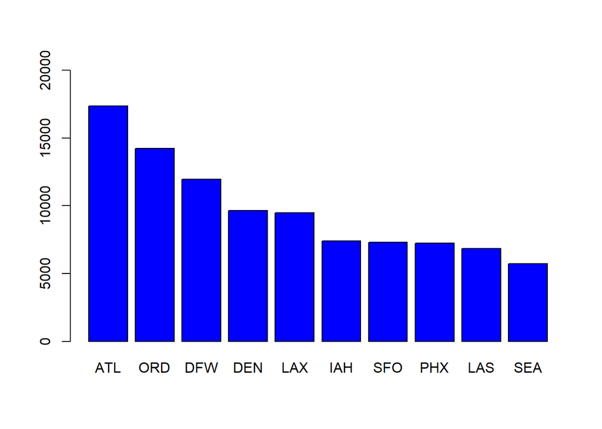

```r
popular_airports <- sort(table(flight_airports$ORIGIN_CODE), decreasing = TRUE )
barplot(popular_airports[1:10], col = "blue", ylim = c(0,20000))
```

También vemos que el jueves es el día de la semana con mayor número de vuelos. Al igual que antes, estamos trabajando con el conjunto de datos reducido, por lo que la información mostrada nos ayuda a ver el día de la semana con mayor número de vuelos pero el número que obtenemos no representa al total del año 2015, si no a nuestra muestra reducida.

```r
sort(table(flight_airports$DAY_OF_WEEK), decreasing = TRUE )
```

```
##
##     4     5     1     3     2     7     6
## 43732 43300 43134 42969 42235 40559 35024
```

A partir de aquí, vamos a identificar los tipos de variables y a quedarnos con los datos que nos interesarán para realizar nuestro estudio.

```r
res <- sapply(vuelos_reduc,class)
kable(data.frame(variables=names(res),clase=as.vector(res)),
      caption = "asignación de clase de objeto R a cada variable")
```

asignación de clase de objeto R a cada variable

| variables | clase |
| --- | --- |
| YEAR | integer |
| MONTH | integer |
| DAY | integer |
| DAY_OF_WEEK | integer |
| AIRLINE | factor |
| FLIGHT_NUMBER | integer |
| TAIL_NUMBER | factor |
| ORIGIN_CODE | factor |
| DESTINATION_AIRPORT | factor |
| SCHEDULED_DEPARTURE | integer |
| DEPARTURE_TIME | integer |
| DEPARTURE_DELAY | integer |
| TAXI_OUT | integer |
| WHEELS_OFF | integer |
| SCHEDULED_TIME | integer |
| ELAPSED_TIME | integer |
| AIR_TIME | integer |
| DISTANCE | integer |
| WHEELS_ON | integer |
| TAXI_IN | integer |
| SCHEDULED_ARRIVAL | integer |
| ARRIVAL_TIME | integer |
| ARRIVAL_DELAY | integer |
| DIVERTED | integer |
| CANCELLED | integer |
| CANCELLATION_REASON | factor |
| AIR_SYSTEM_DELAY | integer |
| SECURITY_DELAY | integer |
| AIRLINE_DELAY | integer |
| LATE_AIRCRAFT_DELAY | integer |
| WEATHER_DELAY | integer |

Vemos la asignación de clase que R le da a cada variable. Sin embargo, tenemos que reasignarle la clase a algunas variables como vemos a continuación.

```r
vuelos[1:4] <- lapply(vuelos[1:4], as.numeric)
vuelos[6] <- lapply(vuelos[6], as.numeric)
vuelos[10:25] <- lapply(vuelos[10:25], as.numeric)
vuelos[27:31] <- lapply(vuelos[27:31], as.numeric)
res <- sapply(vuelos,class)
tabla_datos <- data.frame(variables=names(res),clase=as.vector(res))
kable(tabla_datos,
      caption = "asignación de clase de objeto R a cada variable")
```

asignación de clase de objeto R a cada variable

| variables | clase |
| --- | --- |
| YEAR | numeric |
| MONTH | numeric |
| DAY | numeric |
| DAY_OF_WEEK | numeric |
| AIRLINE | factor |
| FLIGHT_NUMBER | numeric |
| TAIL_NUMBER | factor |
| ORIGIN_AIRPORT | factor |
| DESTINATION_AIRPORT | factor |
| SCHEDULED_DEPARTURE | numeric |
| DEPARTURE_TIME | numeric |
| DEPARTURE_DELAY | numeric |
| TAXI_OUT | numeric |
| WHEELS_OFF | numeric |
| SCHEDULED_TIME | numeric |
| ELAPSED_TIME | numeric |
| AIR_TIME | numeric |
| DISTANCE | numeric |
| WHEELS_ON | numeric |
| TAXI_IN | numeric |
| SCHEDULED_ARRIVAL | numeric |
| ARRIVAL_TIME | numeric |
| ARRIVAL_DELAY | numeric |
| DIVERTED | numeric |
| CANCELLED | numeric |
| CANCELLATION_REASON | factor |
| AIR_SYSTEM_DELAY | numeric |
| SECURITY_DELAY | numeric |
| AIRLINE_DELAY | numeric |
| LATE_AIRCRAFT_DELAY | numeric |
| WEATHER_DELAY | numeric |

Volvemos a ver un resumen con los primeros datos de cada variable:

```r
str(vuelos)
```

```
## 'data.frame':    5819079 obs. of  31 variables:
##  $ YEAR               : num  2015 2015 2015 2015 2015 ...
##  $ MONTH              : num  1 1 1 1 1 1 1 1 1 1 ...
##  $ DAY                : num  1 1 1 1 1 1 1 1 1 1 ...
##  $ DAY_OF_WEEK        : num  4 4 4 4 4 4 4 4 4 4 ...
##  $ AIRLINE            : Factor w/ 14 levels "AA","AS","B6",..: 2 1 12 1 2 4 9 12 1 4 ...
##  $ FLIGHT_NUMBER      : num  98 2336 840 258 135 ...
##  $ TAIL_NUMBER        : Factor w/ 4898 levels "","7819A","7820L",..: 1624 1558 423 1518 2133 1143 2767 2412 1563 3936 ...
##  $ ORIGIN_AIRPORT     : Factor w/ 628 levels "10135","10136",..: 324 483 585 483 584 585 481 483 585 481 ...
##  $ DESTINATION_AIRPORT: Factor w/ 629 levels "10135","10136",..: 585 543 374 511 325 524 524 374 394 328 ...
##  $ SCHEDULED_DEPARTURE: num  5 10 20 20 25 25 25 30 30 30 ...
##  $ DEPARTURE_TIME     : num  2354 2 18 15 24 ...
##  $ DEPARTURE_DELAY    : num  -11 -8 -2 -5 -1 -5 -6 14 -11 3 ...
##  $ TAXI_OUT           : num  21 12 16 15 11 18 11 13 17 12 ...
##  $ WHEELS_OFF         : num  15 14 34 30 35 38 30 57 36 45 ...
```

[output cut: 17 more lines]

De todas las variables cargadas, de momento nos vamos a quedar con las siguientes:  
*MONTH*  
DAY  
*DAY_OF_WEEK*  
AIRLINE  
*ORIGIN_CODE*  
DESTINATION_AIRPORT  
*SCHEDULED_DEPARTURE*  
DEPARTURE_TIME  
*DEPARTURE_DELAY*  
SCHEDULED_TIME  
*ELAPSED_TIME*  
AIR_TIME  
*DISTANCE*  
SCHEDULED_ARRIVAL  
*ARRIVAL_TIME*  
ARRIVAL_DELAY

```r
vuelos_reduc <- dplyr::select(vuelos_reduc, -"YEAR",-"TAIL_NUMBER",-"AIR_SYSTEM_DELAY",-"SECURITY_DELAY",
                              -"AIRLINE_DELAY",-"LATE_AIRCRAFT_DELAY",-"WEATHER_DELAY",
                              -"TAXI_OUT",-"TAXI_IN",-"WHEELS_OFF", -"WHEELS_ON",-"DIVERTED",
                              -"CANCELLED",-"CANCELLATION_REASON")

str(vuelos_reduc)
```

```
## 'data.frame':    290953 obs. of  17 variables:
##  $ MONTH              : int  11 4 4 7 2 7 12 2 3 2 ...
##  $ DAY                : int  16 7 1 28 9 23 24 22 8 8 ...
##  $ DAY_OF_WEEK        : int  1 2 3 2 1 4 4 7 7 7 ...
##  $ AIRLINE            : Factor w/ 14 levels "AA","AS","B6",..: 5 14 4 5 14 1 14 10 8 4 ...
##  $ FLIGHT_NUMBER      : int  5084 1023 2182 4330 1963 2148 1915 4636 2950 2104 ...
##  $ ORIGIN_CODE        : Factor w/ 628 levels "10135","10136",..: 327 358 439 504 483 346 344 593 535 523 ...
##  $ DESTINATION_AIRPORT: Factor w/ 629 levels "10135","10136",..: 614 577 328 459 500 490 368 432 573 393 ...
##  $ SCHEDULED_DEPARTURE: int  825 930 540 1545 1055 600 1125 1956 1145 1935 ...
##  $ DEPARTURE_TIME     : int  819 943 538 1559 1105 553 1124 2002 1242 1932 ...
##  $ DEPARTURE_DELAY    : int  -6 13 -2 14 10 -7 -1 6 57 -3 ...
##  $ SCHEDULED_TIME     : int  128 240 57 108 190 74 80 63 68 137 ...
##  $ ELAPSED_TIME       : int  129 214 47 105 166 68 86 57 68 140 ...
##  $ AIR_TIME           : int  111 201 28 75 153 47 64 35 51 95 ...
##  $ DISTANCE           : int  674 1407 153 468 1363 184 439 216 268 680 ...
##  $ SCHEDULED_ARRIVAL  : int  933 1230 637 1733 1605 714 1345 2059 1253 2052 ...
##  $ ARRIVAL_TIME       : int  928 1217 625 1744 1551 701 1350 2059 1350 2052 ...
##  $ ARRIVAL_DELAY      : int  -5 -13 -12 11 -14 -13 5 0 57 0 ...
```

# **3. Limpieza de los datos**

## 3.1 Elementos vacíos

**¿Los datos contienen ceros o elementos vacíos? ¿Cómo gestionarías cada uno de estos casos?**

En este apartado, vamos a comprobar los valores que contienen nuestras variables para detectar si hay errores en los mismo, si tenemos elementos vacios o ceros o si hay datos fuera de los valores esperados, por ejemplo en las horas, días o meses.

```r
#Comprobamos valore nulos o valores perdidos
sapply(vuelos_reduc, function(x) sum(is.na(x)))
```

```
##               MONTH                 DAY         DAY_OF_WEEK             AIRLINE
##                   0                   0                   0                   0
##       FLIGHT_NUMBER         ORIGIN_CODE DESTINATION_AIRPORT SCHEDULED_DEPARTURE
##                   0                   0                   0                   0
##      DEPARTURE_TIME     DEPARTURE_DELAY      SCHEDULED_TIME        ELAPSED_TIME
##                4309                4309                   1                5303
##            AIR_TIME            DISTANCE   SCHEDULED_ARRIVAL        ARRIVAL_TIME
##                5303                   0                   0                4650
##       ARRIVAL_DELAY
##                5303
```

```r
#Otra forma de sacar los valores nulos
colSums(is.na(vuelos_reduc))
```

```
##               MONTH                 DAY         DAY_OF_WEEK             AIRLINE
##                   0                   0                   0                   0
##       FLIGHT_NUMBER         ORIGIN_CODE DESTINATION_AIRPORT SCHEDULED_DEPARTURE
##                   0                   0                   0                   0
##      DEPARTURE_TIME     DEPARTURE_DELAY      SCHEDULED_TIME        ELAPSED_TIME
##                4309                4309                   1                5303
##            AIR_TIME            DISTANCE   SCHEDULED_ARRIVAL        ARRIVAL_TIME
##                5303                   0                   0                4650
##       ARRIVAL_DELAY
##                5303
```

De los valores nulos que hemos identificado, hacemos una revisión para conocer el motivo de esos valores. Comprobamos que en el caso de los valores nulos en las variables DEPARTURE_DELAY y ARRIVAL_DELAY, se trata de aquellos vuelos que han sido cancelados o desviados, por lo que, como nuestro estudio va a estar basado en los vuelos completados, eliminaremos todos estos valores nulos.

Comprobamos los valores nulos de la columna DEPARTURE_DELAY y ARRIVAL_DELAY:

```r
head(vuelos %>% filter(is.na(vuelos$DEPARTURE_DELAY)))
```

```
##   YEAR MONTH DAY DAY_OF_WEEK AIRLINE FLIGHT_NUMBER TAIL_NUMBER ORIGIN_AIRPORT
## 1 2015     1   1           4      AS           136      N431AS            ANC
## 2 2015     1   1           4      AA          2459      N3BDAA            PHX
## 3 2015     1   1           4      OO          5254      N746SK            MAF
## 4 2015     1   1           4      MQ          2859      N660MQ            SGF
## 5 2015     1   1           4      OO          5460      N583SW            RDD
## 6 2015     1   1           4      MQ          2926      N932MQ            CHS
##   DESTINATION_AIRPORT SCHEDULED_DEPARTURE DEPARTURE_TIME DEPARTURE_DELAY
## 1                 SEA                 135             NA              NA
## 2                 DFW                 200             NA              NA
## 3                 IAH                 510             NA              NA
## 4                 DFW                 525             NA              NA
## 5                 SFO                 530             NA              NA
## 6                 DFW                 545             NA              NA
##   TAXI_OUT WHEELS_OFF SCHEDULED_TIME ELAPSED_TIME AIR_TIME DISTANCE WHEELS_ON
```

[output cut: 27 more lines]

```r
head(vuelos %>% filter(is.na(vuelos$ARRIVAL_DELAY)))
```

```
##   YEAR MONTH DAY DAY_OF_WEEK AIRLINE FLIGHT_NUMBER TAIL_NUMBER ORIGIN_AIRPORT
## 1 2015     1   1           4      AS           136      N431AS            ANC
## 2 2015     1   1           4      AA          2459      N3BDAA            PHX
## 3 2015     1   1           4      OO          5254      N746SK            MAF
## 4 2015     1   1           4      MQ          2859      N660MQ            SGF
## 5 2015     1   1           4      OO          5460      N583SW            RDD
## 6 2015     1   1           4      MQ          2926      N932MQ            CHS
##   DESTINATION_AIRPORT SCHEDULED_DEPARTURE DEPARTURE_TIME DEPARTURE_DELAY
## 1                 SEA                 135             NA              NA
## 2                 DFW                 200             NA              NA
## 3                 IAH                 510             NA              NA
## 4                 DFW                 525             NA              NA
## 5                 SFO                 530             NA              NA
## 6                 DFW                 545             NA              NA
##   TAXI_OUT WHEELS_OFF SCHEDULED_TIME ELAPSED_TIME AIR_TIME DISTANCE WHEELS_ON
```

[output cut: 27 more lines]

De momento como lo que queremos es trabajar con los vuelos retrasados vamos a eliminar los valores nulos de estas variables

```r
vuelos_reduc <- vuelos_reduc[!is.na(vuelos_reduc$DEPARTURE_DELAY),]
vuelos_reduc <- vuelos_reduc[!is.na(vuelos_reduc$ARRIVAL_DELAY),]
```

Comprobamos que ya no quedan valores nulos:

```r
colSums(is.na(vuelos_reduc))
```

```
##               MONTH                 DAY         DAY_OF_WEEK             AIRLINE
##                   0                   0                   0                   0
##       FLIGHT_NUMBER         ORIGIN_CODE DESTINATION_AIRPORT SCHEDULED_DEPARTURE
##                   0                   0                   0                   0
##      DEPARTURE_TIME     DEPARTURE_DELAY      SCHEDULED_TIME        ELAPSED_TIME
##                   0                   0                   0                   0
##            AIR_TIME            DISTANCE   SCHEDULED_ARRIVAL        ARRIVAL_TIME
##                   0                   0                   0                   0
##       ARRIVAL_DELAY
##                   0
```

```r
summary(vuelos_reduc)
```

```
##      MONTH             DAY         DAY_OF_WEEK      AIRLINE      FLIGHT_NUMBER
##  Min.   : 1.000   Min.   : 1.00   Min.   :1.00   WN     :62175   Min.   :   1
##  1st Qu.: 4.000   1st Qu.: 8.00   1st Qu.:2.00   DL     :43369   1st Qu.: 730
##  Median : 7.000   Median :16.00   Median :4.00   AA     :35655   Median :1680
##  Mean   : 6.554   Mean   :15.73   Mean   :3.93   OO     :28784   Mean   :2162
##  3rd Qu.: 9.000   3rd Qu.:23.00   3rd Qu.:6.00   EV     :27742   3rd Qu.:3209
##  Max.   :12.000   Max.   :31.00   Max.   :7.00   UA     :25499   Max.   :7438
##                                                  (Other):62426
##   ORIGIN_CODE     DESTINATION_AIRPORT SCHEDULED_DEPARTURE DEPARTURE_TIME
##  ATL    : 17189   ATL    : 17090      Min.   :   3        Min.   :   1
##  ORD    : 13742   ORD    : 13482      1st Qu.: 916        1st Qu.: 920
##  DFW    : 11625   DFW    : 11753      Median :1323        Median :1329
##  DEN    :  9532   LAX    :  9710      Mean   :1327        Mean   :1334
##  LAX    :  9354   DEN    :  9433      3rd Qu.:1730        3rd Qu.:1739
##  IAH    :  7284   PHX    :  7341      Max.   :2359        Max.   :2400
##  (Other):216924   (Other):216841
##  DEPARTURE_DELAY    SCHEDULED_TIME   ELAPSED_TIME      AIR_TIME
##  Min.   : -68.000   Min.   : 20.0   Min.   : 17.0   Min.   :  8.0
##  1st Qu.:  -5.000   1st Qu.: 85.0   1st Qu.: 82.0   1st Qu.: 60.0
##  Median :  -2.000   Median :123.0   Median :118.0   Median : 94.0
##  Mean   :   9.329   Mean   :141.8   Mean   :136.9   Mean   :113.4
##  3rd Qu.:   7.000   3rd Qu.:174.0   3rd Qu.:169.0   3rd Qu.:144.0
##  Max.   :1380.000   Max.   :705.0   Max.   :685.0   Max.   :661.0
##
##     DISTANCE      SCHEDULED_ARRIVAL  ARRIVAL_TIME  ARRIVAL_DELAY
##  Min.   :  31.0   Min.   :   1      Min.   :   1   Min.   : -87.000
##  1st Qu.: 373.0   1st Qu.:1110      1st Qu.:1058   1st Qu.: -13.000
##  Median : 649.0   Median :1518      Median :1511   Median :  -5.000
##  Mean   : 823.6   Mean   :1492      Mean   :1475   Mean   :   4.482
##  3rd Qu.:1065.0   3rd Qu.:1916      3rd Qu.:1916   3rd Qu.:   8.000
##  Max.   :4983.0   Max.   :2359      Max.   :2400   Max.   :1384.000
##
```

Comprobamos los datos de meses y días, por ver que no hay valores extraños. También revisaremos que no hay distancias ni tiempos horarios negativos.

```r
#Comprobamos si hay valores extraños en las variables día, día de la semana y mes
month_wrong <- which(vuelos_reduc$MONTH > 12 | vuelos_reduc$MONTH < 1)
month_wrong
```

```
## integer(0)
```

```r
day_wrong <- which(vuelos_reduc$DAY > 31 | vuelos_reduc$DAY < 1)
day_wrong
```

```
## integer(0)
```

```r
day_week_wrong <- which(vuelos_reduc$DAY_OF_WEEK > 7 | vuelos_reduc$DAY_OF_WEEK <1)
day_week_wrong
```

```
## integer(0)
```

Comprobamos que los valores de distancias y horas en base a los valores mínimos y máximos son correctos. En el caso de los aeropuertos, conocemos que hay aeropuertos que tienen diferente nomenclatura para un mismo aeropuerto, de momento no vamos a realizar ninguna modificación sobre este dato, supondremos que son aeropuertos diferentes.

## 3.2 Identificación y tratamiento de valores extremos

Vamos a identificar los posibles valores extermos que tenemos en las variables de tiempo y distancia. En base a los resultados decidiremos que acciones tomar con estas variables.

Para ello vamos representar las variables con un diagrama de cajas y bigotes que nos mostrará visualmente dichas variables a través de sus cuartiles.

Las lineas que salen de las cajas se conocen como “bigotes” e indican la variabilidad fuera de los cuartiles superior e inferior. Los valores extremos (outliers) se representarán como puntos individuales. Dentro de la caja, la línea que vemos nos muestra la mediana.

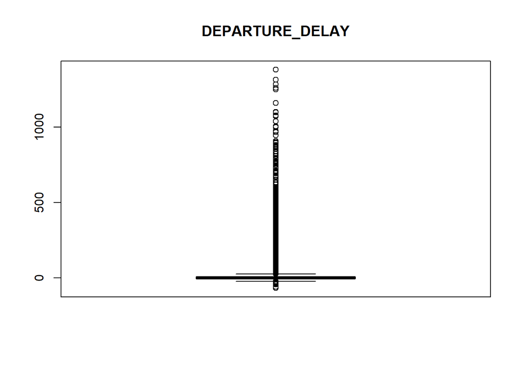

```r
boxplot(vuelos_reduc$DEPARTURE_DELAY, main="DEPARTURE_DELAY")
```

```r
table(vuelos_reduc$DEPARTURE_DELAY)
```

```
##
##   -68   -61   -44   -39   -38   -37   -35   -34   -33   -31   -30   -29   -28
##     1     1     1     1     1     1     1     3     1     3     2     3     8
##   -27   -26   -25   -24   -23   -22   -21   -20   -19   -18   -17   -16   -15
##     3     9     9    18    29    40    39    62    92   164   187   315   525
##   -14   -13   -12   -11   -10    -9    -8    -7    -6    -5    -4    -3    -2
##   746  1100  1658  2464  5224  5971  8700 12221 16301 22017 22123 22739 21632
##    -1     0     1     2     3     4     5     6     7     8     9    10    11
## 19241 16350  7970  6060  5175  4630  4245  3796  3392  3170  2947  2794  2502
##    12    13    14    15    16    17    18    19    20    21    22    23    24
##  2310  2230  2000  1991  1709  1784  1587  1529  1474  1344  1280  1226  1091
##    25    26    27    28    29    30    31    32    33    34    35    36    37
##  1206  1012  1004   930   909   912   809   799   783   719   789   679   664
##    38    39    40    41    42    43    44    45    46    47    48    49    50
##   602   572   546   543   544   507   493   493   512   452   413   424   468
```

[output cut: 80 more lines]

```r
table(boxplot.stats(vuelos_reduc$DEPARTURE_DELAY)$out)
```

```
##
##  -68  -61  -44  -39  -38  -37  -35  -34  -33  -31  -30  -29  -28  -27  -26  -25
##    1    1    1    1    1    1    1    3    1    3    2    3    8    3    9    9
##  -24   26   27   28   29   30   31   32   33   34   35   36   37   38   39   40
##   18 1012 1004  930  909  912  809  799  783  719  789  679  664  602  572  546
##   41   42   43   44   45   46   47   48   49   50   51   52   53   54   55   56
##  543  544  507  493  493  512  452  413  424  468  403  413  357  373  352  327
##   57   58   59   60   61   62   63   64   65   66   67   68   69   70   71   72
##  339  325  337  328  319  303  293  276  298  266  273  283  256  246  219  216
##   73   74   75   76   77   78   79   80   81   82   83   84   85   86   87   88
##  234  223  193  200  199  197  207  183  186  183  174  192  160  164  155  173
##   89   90   91   92   93   94   95   96   97   98   99  100  101  102  103  104
##  157  155  148  134  149  131  149  146  138  126  116  156  130  123  147  128
##  105  106  107  108  109  110  111  112  113  114  115  116  117  118  119  120
##  124  123  125  130  100  121   93   97  118  100   88   91   99   87   98   92
```

[output cut: 56 more lines]

En las tablas podemos observar con más detalle los valores que toma esta variable y, comprobamos la disparidad de los retrasos.

Los valores negativos nos indican que los vuelos salieron antes de su hora programada en un primer momento.

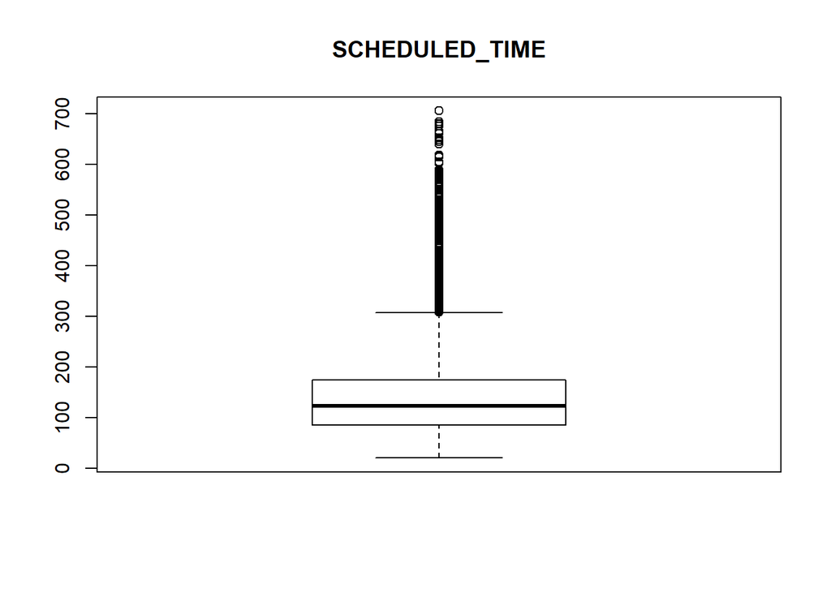

```r
boxplot(vuelos_reduc$SCHEDULED_TIME, main="SCHEDULED_TIME")
```

```r
table(vuelos_reduc$SCHEDULED_TIME)
```

```
##
##   20   21   22   23   24   25   26   29   30   31   32   33   34   35   36   37
##    3    5    3    9    8    6    1    5   24    5  141  232  109  213  182  481
##   38   39   40   41   42   43   44   45   46   47   48   49   50   51   52   53
##  141  290  147  144  221  374  443  448  454  501  411  576 1060  732  766  812
##   54   55   56   57   58   59   60   61   62   63   64   65   66   67   68   69
##  810 1649  790  839  924  929 3247  894 1019 1182 1184 4481 1211 1350 1362 1346
##   70   71   72   73   74   75   76   77   78   79   80   81   82   83   84   85
## 4699 1345 1439 1436 1477 5250 1741 1545 1518 1606 5535 1523 1587 1572 1496 5735
##   86   87   88   89   90   91   92   93   94   95   96   97   98   99  100  101
## 1494 1525 1698 1516 5096 1447 1574 1556 1628 4202 1593 1513 1514 1510 3645 1375
##  102  103  104  105  106  107  108  109  110  111  112  113  114  115  116  117
## 1274 1410 1430 3633 1192 1435 1412 1554 3860 1338 1441 1464 1481 3667 1461 1285
##  118  119  120  121  122  123  124  125  126  127  128  129  130  131  132  133
## 1379 1531 3382 1170 1146 1338 1408 3143 1159 1183 1159 1235 2932 1099  995 1073
```

[output cut: 52 more lines]

En el caso de la variable SCHEDULED_TIME (tiempo programado de vuelo) sí podemos apreciar mejor la caja y los bigotes del diagrama. Vemos que todos los valores extremos se encuentran por encima del extremo superior por lo que todos nos indican que el tiempo programado de vuelo ha sido excedido. Al igual que ocurría con la variable anteriormente analizada, de esta variable nos interesan todos sus valores por lo que no podemos eliminar sus valores extremos ya que estaríamos desperdiciando información importante.

En las tablas vemos con más detalles sus valores.

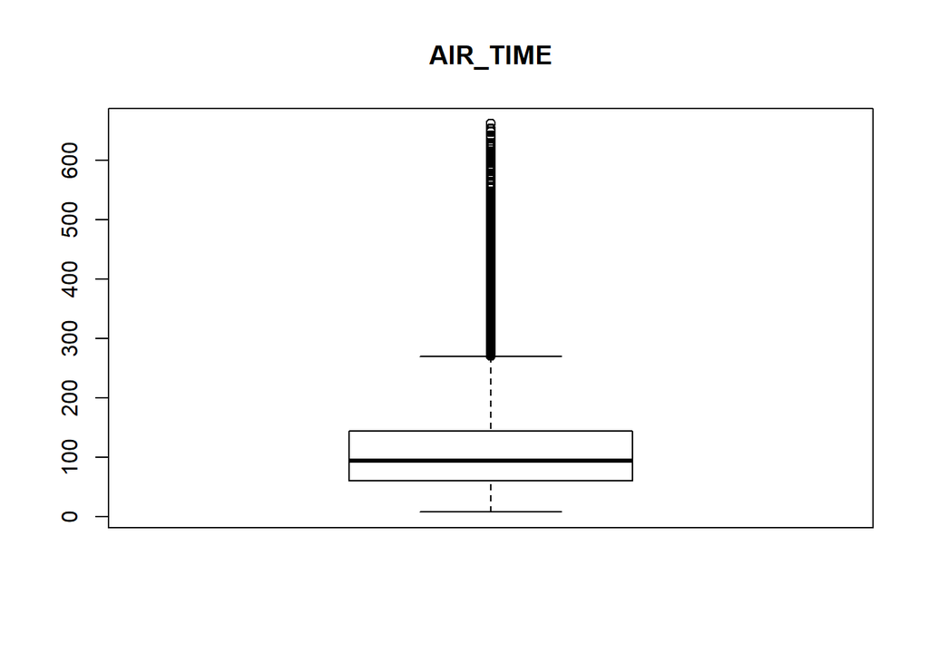

```r
boxplot(vuelos_reduc$AIR_TIME, main="AIR_TIME")
```

```r
table(vuelos_reduc$AIR_TIME)
```

```
##
##    8    9   10   11   12   13   14   15   16   17   18   19   20   21   22   23
##    3    7    5    4    5   10   32   56  100  148  196  277  456  649  766  723
##   24   25   26   27   28   29   30   31   32   33   34   35   36   37   38   39
##  683  743  780  879 1079 1151 1170 1197 1263 1307 1335 1420 1505 1568 1661 1833
##   40   41   42   43   44   45   46   47   48   49   50   51   52   53   54   55
## 2145 2274 2406 2397 2449 2426 2368 2200 2191 2238 2248 2249 2301 2394 2335 2303
##   56   57   58   59   60   61   62   63   64   65   66   67   68   69   70   71
## 2465 2308 2321 2383 2384 2447 2495 2612 2484 2527 2494 2338 2264 2152 2129 1983
##   72   73   74   75   76   77   78   79   80   81   82   83   84   85   86   87
## 1942 1878 1864 1961 1938 1960 1935 1972 2079 2105 2047 2099 2124 2095 2080 2145
##   88   89   90   91   92   93   94   95   96   97   98   99  100  101  102  103
## 2112 2030 1994 1909 1825 1847 1770 1669 1633 1695 1572 1559 1600 1583 1458 1467
##  104  105  106  107  108  109  110  111  112  113  114  115  116  117  118  119
## 1434 1532 1445 1472 1507 1473 1486 1427 1382 1360 1401 1452 1464 1487 1457 1453
```

[output cut: 58 more lines]

Para la vairable AIR_TIME (tiempo desde el despegue hasta el aterrizaje) vemos que la mayoría de vuelos duran entre 50 y 150 minutos aproximadamente, llegando el extremo superior a prácticamente 300 minutos. A partir de este valor nos encontramos con los datos extremos llegando hasta prácticamente los 700 minutos en su valor máximo. Dado que los valores extremos representan valores reales de duraciones de vuelo no nos interesa quitar dichos valores de la muestra ya que no se deben a posibles errores y nos aportan información valiosa. En la tabla vemos de manera más detallada la información de dicha variable.

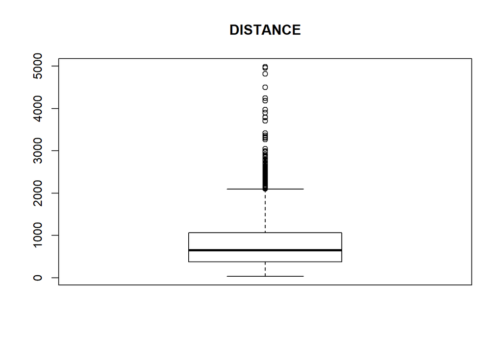

```r
boxplot(vuelos_reduc$DISTANCE, main="DISTANCE")
```

```r
table(boxplot.stats(vuelos_reduc$DISTANCE)$out)
```

```
##
## 2105 2106 2110 2116 2125 2130 2133 2136 2139 2149 2153 2158 2161 2165 2172 2173
##   69  179   12   28  212    6  227   24  340   48  261   50   41   68  109  134
## 2174 2176 2182 2218 2227 2237 2239 2244 2248 2253 2254 2267 2279 2282 2288 2295
##  164  271  292  242  177   34   93   17  382  133   41   30  103   31  376   75
## 2296 2297 2300 2304 2306 2311 2327 2329 2330 2335 2338 2342 2343 2345 2349 2350
##  218   34  138    9  114  112   29  202    4   86  139  393  145   35   86   35
## 2354 2355 2358 2360 2367 2370 2378 2381 2384 2393 2398 2400 2402 2404 2405 2406
##    8   90   30    9   84   82  143  108   16    1  234   47  409   46   42   16
## 2409 2411 2415 2417 2419 2422 2425 2434 2442 2446 2447 2449 2454 2457 2458 2462
##   63   22    6   46  366  225  105  133   61  296   80   26  607   48    8   28
## 2465 2466 2475 2486 2496 2504 2519 2520 2521 2537 2541 2552 2554 2556 2562 2565
##   99   28 1225  306  165  149   63   30  290   45   27   40   56  596   72  541
## 2569 2576 2583 2584 2585 2586 2588 2599 2602 2603 2607 2611 2614 2615 2631 2636
##   40   22   30  108  109  913   95   12   29   77   13  420   68  128   12    5
## 2640 2676 2677 2681 2688 2689 2694 2701 2704 2715 2717 2724 2762 2777 2785 2797
##  120   21  163    9   58   10   10   59  446   14   29   38   88   26   10    5
## 2845 2846 2860 2874 2917 2979 2994 3043 3266 3302 3329 3365 3414 3417 3711 3784
##   54   69   40    3  120   37   37    9    8   18   15   23    7   12   52   77
## 3801 3904 3972 4184 4243 4502 4817 4962 4983
##   33   36    4   16   27   42   12   31   36
```

Para la varialbe DISTANCE (distancia en millas) observamos que la mayor parte de los vuelos transcurren en distancias de hasta 1000 millas aproximadamente, llegando el extremo superior a las 2000 millas aproximadamente. A partir de las 2000 millas nos encontramos los valores outliers, concentrandose la mayor parte de ellos hasta las 3000 millas. Vuelos de entre 3000 millas hasta 5000 millas nos encontramos muy pocos como observamos tanto en el diagrama como en la tabla.

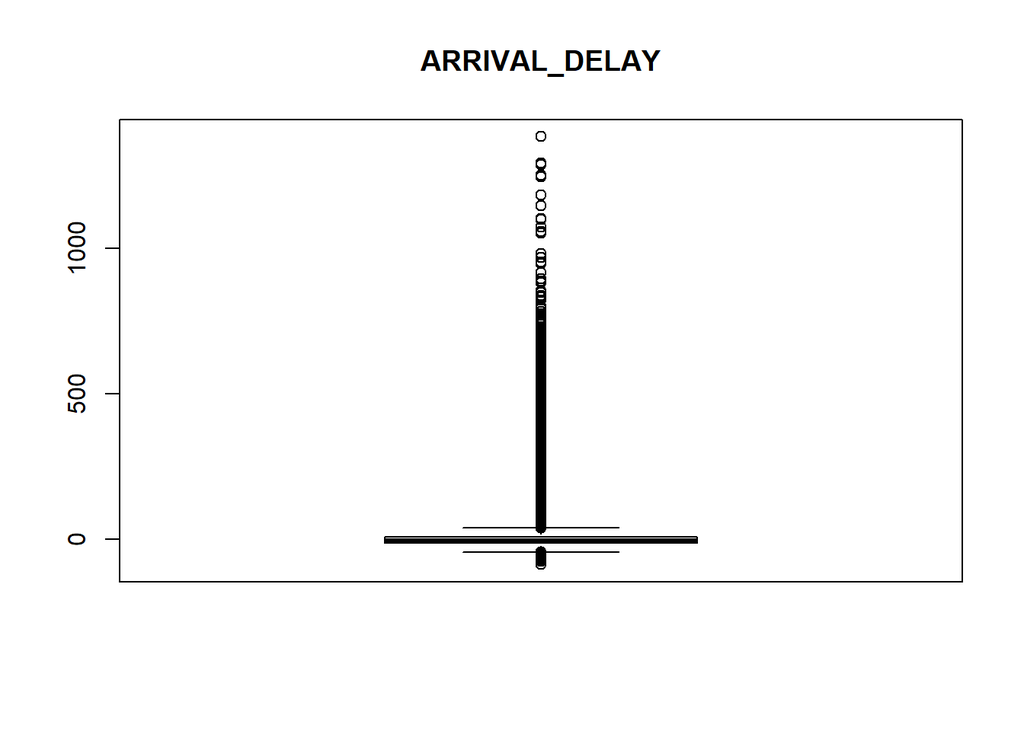

```r
boxplot(vuelos_reduc$ARRIVAL_DELAY, main="ARRIVAL_DELAY")
```

```r
table(vuelos_reduc$ARRIVAL_DELAY)
```

```
##
##  -87  -77  -75  -72  -71  -69  -67  -66  -65  -63  -62  -61  -60  -59  -58  -57
##    1    1    1    1    1    1    1    1    1    3    5    4    6    1    9    9
##  -56  -55  -54  -53  -52  -51  -50  -49  -48  -47  -46  -45  -44  -43  -42  -41
##   10   11   17   19   24   24   27   48   53   40   66   92   92  109  137  143
##  -40  -39  -38  -37  -36  -35  -34  -33  -32  -31  -30  -29  -28  -27  -26  -25
##  180  216  236  278  344  460  530  574  757  804 1018 1219 1366 1653 1922 2235
##  -24  -23  -22  -21  -20  -19  -18  -17  -16  -15  -14  -13  -12  -11  -10   -9
## 2596 2934 3357 3963 4403 5004 5541 6005 6464 7024 7511 7803 8174 8471 8789 8797
##   -8   -7   -6   -5   -4   -3   -2   -1    0    1    2    3    4    5    6    7
## 8966 8711 8610 8127 7887 7416 7038 6688 6359 5627 5288 4948 4596 4313 3837 3646
##    8    9   10   11   12   13   14   15   16   17   18   19   20   21   22   23
## 3241 3063 2906 2609 2474 2397 2183 1981 1927 1718 1641 1577 1469 1323 1433 1286
##   24   25   26   27   28   29   30   31   32   33   34   35   36   37   38   39
## 1201 1157 1049 1030  965  887  923  842  769  819  750  732  627  690  687  594
```

[output cut: 66 more lines]

En resumen, el conjunto de datos que estamos tratando tiene muchos valores muy dispersos, de momento no vamos a hacer nada con ellos, los mantendremos y en algunos casos concretos, si fuese necesario, realizaremos los filtrados correspondientes.

# **4. Análisis de los datos**

## 4.1 Selección de los grupos de datos

**Selección de los grupos de datos que se quieren analizar/comparar (planificación de los análisis a aplicar)**  
Para poder trabajar mejor con las variables de tiempo, y dado que no nos van a interesar en principio los minutos vamos a dejar solamente las horas para poder realizar ciertos análisis de este dato.

```r
vuelos_reduc$SCHEDULED_DEPARTURE_HOUR=format(round(trunc(vuelos_reduc$SCHEDULED_DEPARTURE/100),digits=0), nsmall=0)
vuelos_reduc$SCHEDULED_DEPARTURE_HOUR <- as.numeric(vuelos_reduc$SCHEDULED_DEPARTURE_HOUR)
head(vuelos_reduc$SCHEDULED_DEPARTURE_HOUR)
```

```
## [1]  8  9  5 15 10  6
```

```r
table(vuelos_reduc$SCHEDULED_DEPARTURE_HOUR)
```

```
##
##     0     1     2     3     4     5     6     7     8     9    10    11    12
##   736   297    60    34    33  5756 20063 19297 18745 17405 18383 17633 17571
##    13    14    15    16    17    18    19    20    21    22    23
## 17852 16233 18195 16228 19053 16117 16315 12733  9072  5695  2144
```

```r
vuelos_reduc$DEPARTURE_HOUR=format(round(trunc(vuelos_reduc$DEPARTURE_TIME/100),digits=0), nsmall=0)
vuelos_reduc$DEPARTURE_HOUR <- as.factor(vuelos_reduc$DEPARTURE_HOUR)
head(vuelos_reduc$DEPARTURE_HOUR)
```

```
## [1]  8  9  5 15 11  5
## 25 Levels:  0  1  2  3  4  5  6  7  8  9 10 11 12 13 14 15 16 17 18 19 ... 24
```

```r
table(vuelos_reduc$DEPARTURE_HOUR)
```

```
##
##     0     1     2     3     4     5     6     7     8     9    10    11    12
##  1258   489   121    48   493  9758 18295 17385 17678 16948 17972 17332 17343
##    13    14    15    16    17    18    19    20    21    22    23    24
## 17092 16410 17628 16413 18053 15904 16375 13381  9887  6556  2811    20
```

```r
vuelos_reduc$ARRIVAL_HOUR=format(round(trunc(vuelos_reduc$ARRIVAL_TIME/100),digits=0), nsmall=0)
vuelos_reduc$ARRIVAL_HOUR <- as.factor(vuelos_reduc$ARRIVAL_HOUR)
head(vuelos_reduc$ARRIVAL_HOUR)
```

```
## [1]  9 12  6 17 15  7
## 25 Levels:  0  1  2  3  4  5  6  7  8  9 10 11 12 13 14 15 16 17 18 19 ... 24
```

```r
table(vuelos_reduc$ARRIVAL_HOUR)%>% knitr::kable("html")  %>% kable_styling(position='center', font_size=12, fixed_thead=list(enabled=T))
```

| Var1 | Freq |
| --- | --- |
| 0 | 4963 |
| 1 | 1524 |
| 2 | 471 |
| 3 | 181 |
| 4 | 606 |
| 5 | 2053 |
| 6 | 4850 |
| 7 | 10154 |
| 8 | 13810 |
| 9 | 16512 |
| 10 | 16853 |
| 11 | 17020 |
| 12 | 16798 |
| 13 | 16815 |
| 14 | 17228 |
| 15 | 16374 |
| 16 | 18418 |
| 17 | 17300 |
| 18 | 17478 |
| 19 | 17006 |
| 20 | 17359 |
| 21 | 16372 |
| 22 | 14323 |
| 23 | 11033 |
| 24 | 149 |

Creamos una nueva variables que identifique el retraso total, en base a la perdida o ganancia en el tiempo de llegada frente al tiempo de adelanto o retraso en la salida

```r
vuelos_reduc <- mutate(vuelos_reduc, RETRASO_TOTAL=ARRIVAL_DELAY - DEPARTURE_DELAY)

str(vuelos_reduc)
```

```
## 'data.frame':    285650 obs. of  21 variables:
##  $ MONTH                   : int  11 4 4 7 2 7 12 2 3 2 ...
##  $ DAY                     : int  16 7 1 28 9 23 24 22 8 8 ...
##  $ DAY_OF_WEEK             : int  1 2 3 2 1 4 4 7 7 7 ...
##  $ AIRLINE                 : Factor w/ 14 levels "AA","AS","B6",..: 5 14 4 5 14 1 14 10 8 4 ...
##  $ FLIGHT_NUMBER           : int  5084 1023 2182 4330 1963 2148 1915 4636 2950 2104 ...
##  $ ORIGIN_CODE             : Factor w/ 628 levels "10135","10136",..: 327 358 439 504 483 346 344 593 535 523 ...
##  $ DESTINATION_AIRPORT     : Factor w/ 629 levels "10135","10136",..: 614 577 328 459 500 490 368 432 573 393 ...
##  $ SCHEDULED_DEPARTURE     : int  825 930 540 1545 1055 600 1125 1956 1145 1935 ...
##  $ DEPARTURE_TIME          : int  819 943 538 1559 1105 553 1124 2002 1242 1932 ...
##  $ DEPARTURE_DELAY         : int  -6 13 -2 14 10 -7 -1 6 57 -3 ...
##  $ SCHEDULED_TIME          : int  128 240 57 108 190 74 80 63 68 137 ...
##  $ ELAPSED_TIME            : int  129 214 47 105 166 68 86 57 68 140 ...
##  $ AIR_TIME                : int  111 201 28 75 153 47 64 35 51 95 ...
##  $ DISTANCE                : int  674 1407 153 468 1363 184 439 216 268 680 ...
##  $ SCHEDULED_ARRIVAL       : int  933 1230 637 1733 1605 714 1345 2059 1253 2052 ...
##  $ ARRIVAL_TIME            : int  928 1217 625 1744 1551 701 1350 2059 1350 2052 ...
##  $ ARRIVAL_DELAY           : int  -5 -13 -12 11 -14 -13 5 0 57 0 ...
##  $ SCHEDULED_DEPARTURE_HOUR: num  8 9 5 15 10 6 11 19 11 19 ...
##  $ DEPARTURE_HOUR          : Factor w/ 25 levels " 0"," 1"," 2",..: 9 10 6 16 12 6 12 21 13 20 ...
##  $ ARRIVAL_HOUR            : Factor w/ 25 levels " 0"," 1"," 2",..: 10 13 7 18 16 8 14 21 14 21 ...
##  $ RETRASO_TOTAL           : int  1 -26 -10 -3 -24 -6 6 -6 0 3 ...
```

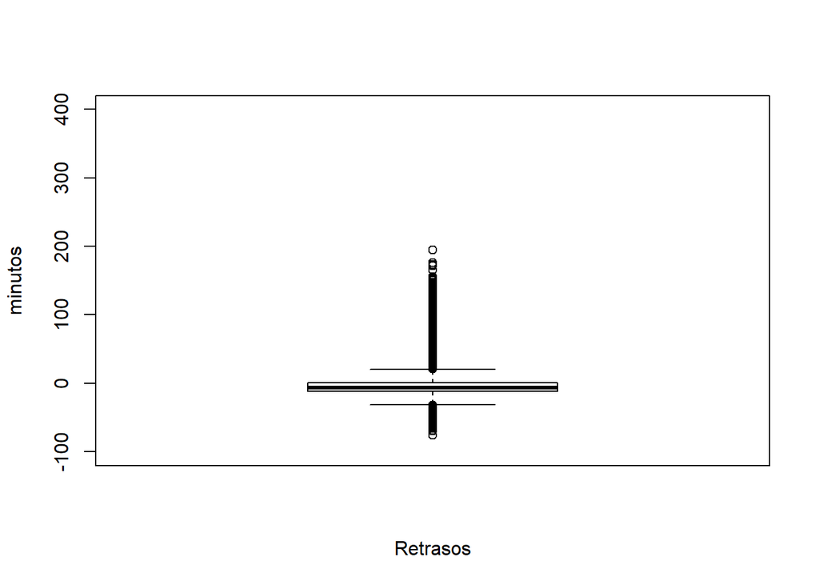

```r
boxplot(vuelos_reduc$RETRASO_TOTAL , xlab="Retrasos", ylab="minutos", ylim=c(-100, 400) )
```

```r
table(boxplot.stats(vuelos_reduc$RETRASO_TOTAL)$out)
```

```
##
## -76 -70 -69 -66 -64 -63 -62 -61 -60 -59 -58 -57 -56 -55 -54 -53 -52 -51 -50 -49
##   1   1   1   1   1   1   4   2   2   2   1   5   5  11   9  13  29  15  27  36
## -48 -47 -46 -45 -44 -43 -42 -41 -40 -39 -38 -37 -36 -35 -34 -33 -32  21  22  23
##  34  39  61  60  68  70 106 116 139 173 167 230 286 347 391 449 575 746 725 613
##  24  25  26  27  28  29  30  31  32  33  34  35  36  37  38  39  40  41  42  43
## 561 490 494 435 382 351 302 250 269 260 218 222 203 202 150 162 131 142  98 111
##  44  45  46  47  48  49  50  51  52  53  54  55  56  57  58  59  60  61  62  63
## 104 107  94  60  84  85  95  62  53  65  56  65  46  52  46  48  42  35  31  26
##  64  65  66  67  68  69  70  71  72  73  74  75  76  77  78  79  80  81  82  83
##  30  25  14  25  21  17  24  18  18  19  24  19  23  14  18  17  18  14  10   9
##  84  85  86  87  88  89  90  91  92  93  94  95  96  97  98  99 100 101 102 103
##  10  15  10  13  14   2   4   5   3   9   5   6   3   6   8   4   3   5   3   3
## 104 105 106 107 108 109 110 111 112 113 114 115 116 117 118 119 120 121 122 123
##   9   6   5   5   4   5   5   3   6   2   4   3   4   3   5   3   3   2   2   1
## 125 126 127 128 129 130 131 132 134 136 137 139 140 141 142 143 144 145 146 147
##   1   1   3   3   3   3   5   2   3   1   1   1   1   1   2   1   2   1   2   1
## 148 150 152 153 156 165 172 173 176 195
##   1   1   1   1   1   1   1   1   1   1
```

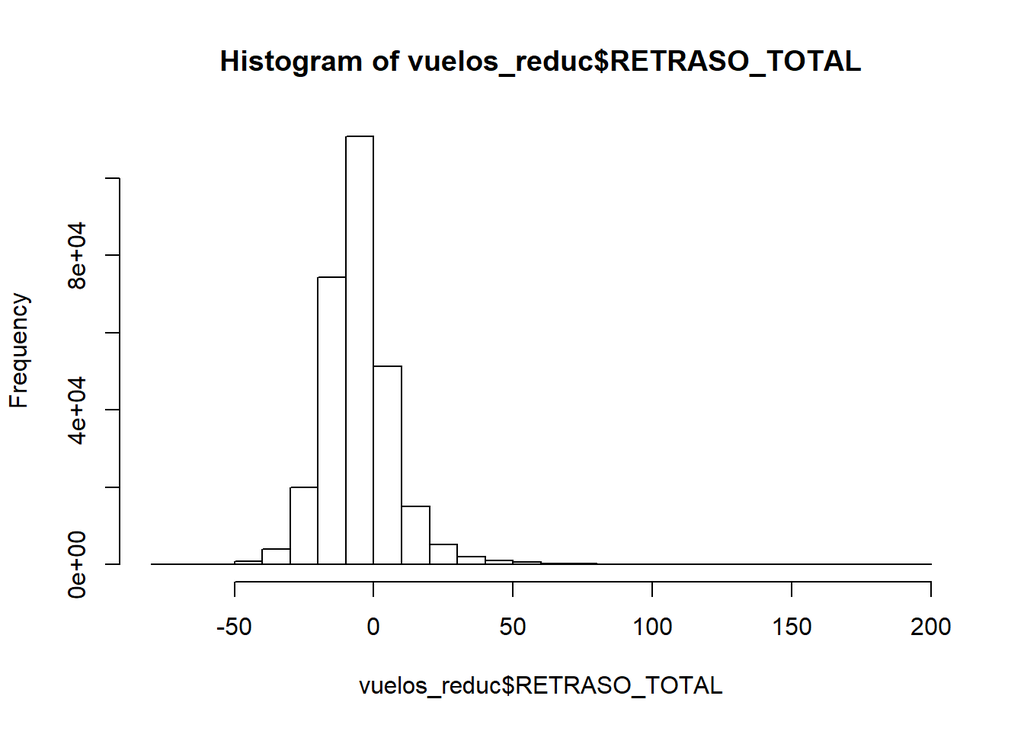

```r
hist(vuelos_reduc$RETRASO_TOTAL)
```

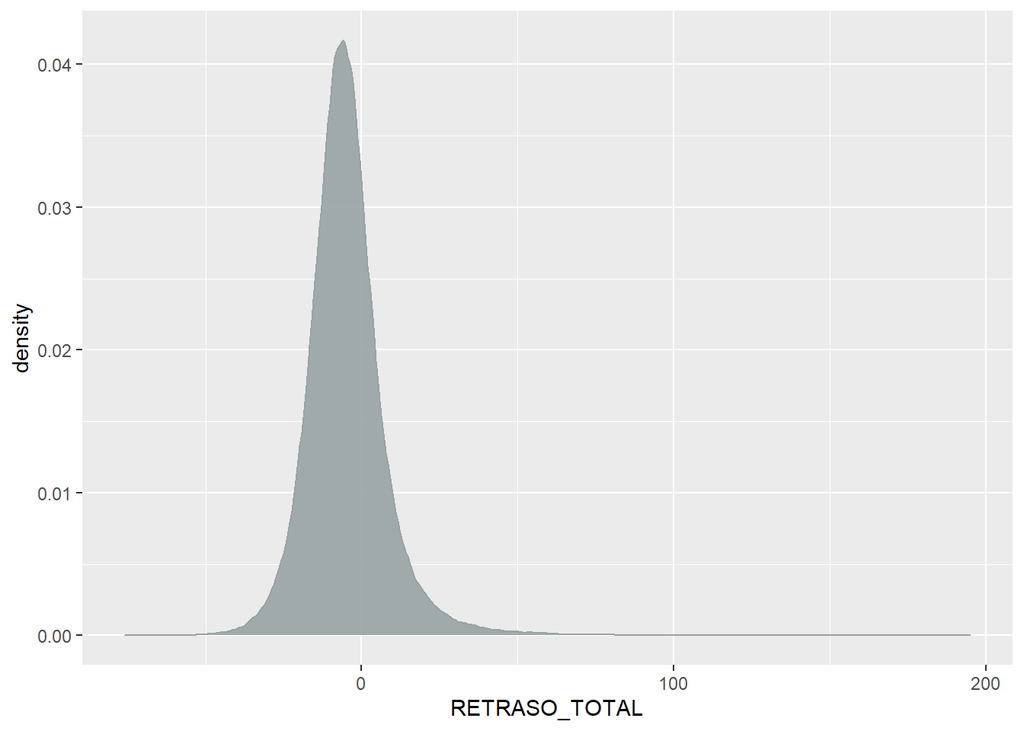

```r
vuelos_reduc %>%
  ggplot( aes(x=RETRASO_TOTAL)) +
  geom_density(fill="#99A3A4", color="#99A3A4", alpha=0.9)
```

En los gráficos podemos ver como, del mismo modo que se tenía en el gráfico de cajas y bigotes del apartado 3 para las variables DEPARTURE_DELAY y ARRIVAL_DELAY, para esta nueva variable, se tiene un comportamiento similar, como era de esperar. La gran mayoría de los vuelos se concentran alrededor del 0, es decir que los vuelos salen y llegan en los tiempos establecidos. Sin embargo el gráfico se alarga a ambos lados, sobre todo hacia la derecha, debido a la gran dispersión de tiempos de vuelos retrasados (diferencia positiva).

## 4.2 Comprobación de la normalidad y homogeneidad de la varianza

Utilizaremos la prueba Shapiro-Wilk test para comprobar la normalidad de la muestra para los valores DEPARTURE_DELAY, ARRIVAL_DELAY y DISTANCE

```r
shapiro.test(vuelos_reduc$DEPARTURE_DELAY[1:5000])
```

```
##
##  Shapiro-Wilk normality test
##
## data:  vuelos_reduc$DEPARTURE_DELAY[1:5000]
## W = 0.45789, p-value < 2.2e-16
```

```r
shapiro.test(vuelos_reduc$ARRIVAL_DELAY[1:5000])
```

```
##
##  Shapiro-Wilk normality test
##
## data:  vuelos_reduc$ARRIVAL_DELAY[1:5000]
## W = 0.58009, p-value < 2.2e-16
```

```r
shapiro.test(vuelos_reduc$DISTANCE[1:5000])
```

```
##
##  Shapiro-Wilk normality test
##
## data:  vuelos_reduc$DISTANCE[1:5000]
## W = 0.88101, p-value < 2.2e-16
```

```r
shapiro.test(vuelos_reduc$RETRASO_TOTAL[1:5000])
```

```
##
##  Shapiro-Wilk normality test
##
## data:  vuelos_reduc$RETRASO_TOTAL[1:5000]
## W = 0.91736, p-value < 2.2e-16
```

La prueba de Saphiro-Wilk, solo es posible para un máximo de 5000 registros, por lo que hemos realizado la prueba con un subconjunto con esa cantidad, y nos da como resultado que debemos rechazar la hipótesis nula, es decir, nos indicaría que las variables no siguen una distribución normal. Sin embargo, por el teorema central del límite, la distribución de la media de cualquier muestra de datos se considera cada vez más normal según aumenta el tamaño de la misma y para muestras superiores con N>30 se puede suponer normalidad, dado que podría aproximarse a una disribución normal.

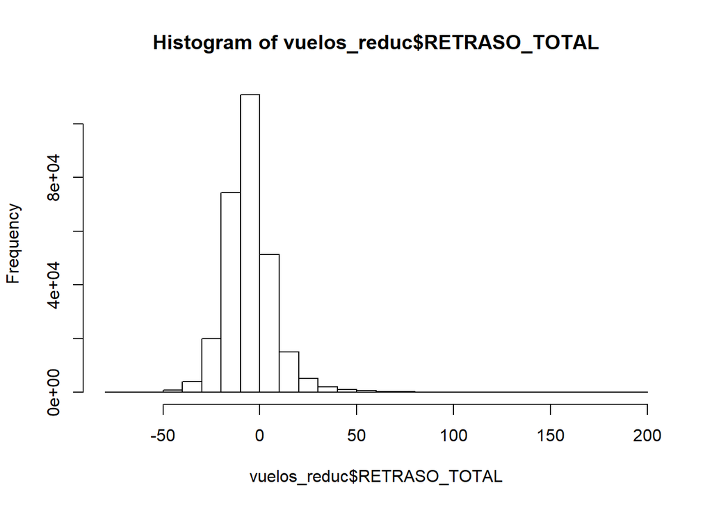

```r
hist(vuelos_reduc$RETRASO_TOTAL)
```

Aparentemenete, para esta variable, según el gráfico podríamos decir que la variable sigue una distribución normal.  
Vamos a intentar generar Q-QPlot para mostrar gráficamente si la muestra sigue una distribución normal.

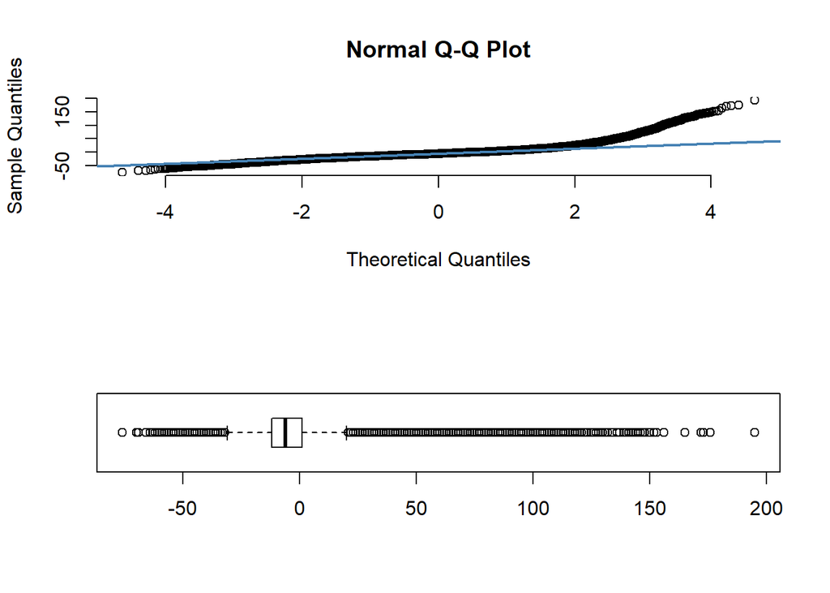

```r
par(mfrow=c(2,1))
qqnorm(vuelos_reduc$RETRASO_TOTAL, pch = 1, frame = FALSE)
qqline(vuelos_reduc$RETRASO_TOTAL, col = "steelblue", lwd = 2)
boxplot(vuelos_reduc$RETRASO_TOTAL, horizontal=T)
```

Contrastamos el gráfico Q-QPlot contra el gráfico de cajas, para ver el comportamiento. En el gráfico de arriba, podemos ver que los valores de la variable no se pegan a la recta, de hecho, se levanta hacia la parte de la derecha despegándose de la recta y solo unos cuantos valores centrales se tienen alrededor de la recta. Esto nos está identificando que esta variable tiene una gran cantidad de valores extremos que hacen que tengamos que preguntarnos si la variable sigue una distribución normal.

Como no tenemos seguridad de si la población que estamos estudiando sigue una distribución normal, utilizaremos el test de Levene para comprobar la homogeneidad de la varianza u homocedasticidad. Compararemos nuestra variable con la variable DAY_OF_WEEK (realizamos una agrupación de los datos por día de la semana). Tomaremos como hipótesis nula la semajanza de variables y como hipótesis alternativa la no igualdad en la varianza de las varibales con un índice de significación ${\alpha}$=0.05

```r
str(vuelos_reduc)
```

```
## 'data.frame':    285650 obs. of  21 variables:
##  $ MONTH                   : int  11 4 4 7 2 7 12 2 3 2 ...
##  $ DAY                     : int  16 7 1 28 9 23 24 22 8 8 ...
##  $ DAY_OF_WEEK             : int  1 2 3 2 1 4 4 7 7 7 ...
##  $ AIRLINE                 : Factor w/ 14 levels "AA","AS","B6",..: 5 14 4 5 14 1 14 10 8 4 ...
##  $ FLIGHT_NUMBER           : int  5084 1023 2182 4330 1963 2148 1915 4636 2950 2104 ...
##  $ ORIGIN_CODE             : Factor w/ 628 levels "10135","10136",..: 327 358 439 504 483 346 344 593 535 523 ...
##  $ DESTINATION_AIRPORT     : Factor w/ 629 levels "10135","10136",..: 614 577 328 459 500 490 368 432 573 393 ...
##  $ SCHEDULED_DEPARTURE     : int  825 930 540 1545 1055 600 1125 1956 1145 1935 ...
##  $ DEPARTURE_TIME          : int  819 943 538 1559 1105 553 1124 2002 1242 1932 ...
##  $ DEPARTURE_DELAY         : int  -6 13 -2 14 10 -7 -1 6 57 -3 ...
##  $ SCHEDULED_TIME          : int  128 240 57 108 190 74 80 63 68 137 ...
##  $ ELAPSED_TIME            : int  129 214 47 105 166 68 86 57 68 140 ...
##  $ AIR_TIME                : int  111 201 28 75 153 47 64 35 51 95 ...
##  $ DISTANCE                : int  674 1407 153 468 1363 184 439 216 268 680 ...
##  $ SCHEDULED_ARRIVAL       : int  933 1230 637 1733 1605 714 1345 2059 1253 2052 ...
##  $ ARRIVAL_TIME            : int  928 1217 625 1744 1551 701 1350 2059 1350 2052 ...
##  $ ARRIVAL_DELAY           : int  -5 -13 -12 11 -14 -13 5 0 57 0 ...
##  $ SCHEDULED_DEPARTURE_HOUR: num  8 9 5 15 10 6 11 19 11 19 ...
##  $ DEPARTURE_HOUR          : Factor w/ 25 levels " 0"," 1"," 2",..: 9 10 6 16 12 6 12 21 13 20 ...
##  $ ARRIVAL_HOUR            : Factor w/ 25 levels " 0"," 1"," 2",..: 10 13 7 18 16 8 14 21 14 21 ...
##  $ RETRASO_TOTAL           : int  1 -26 -10 -3 -24 -6 6 -6 0 3 ...
```

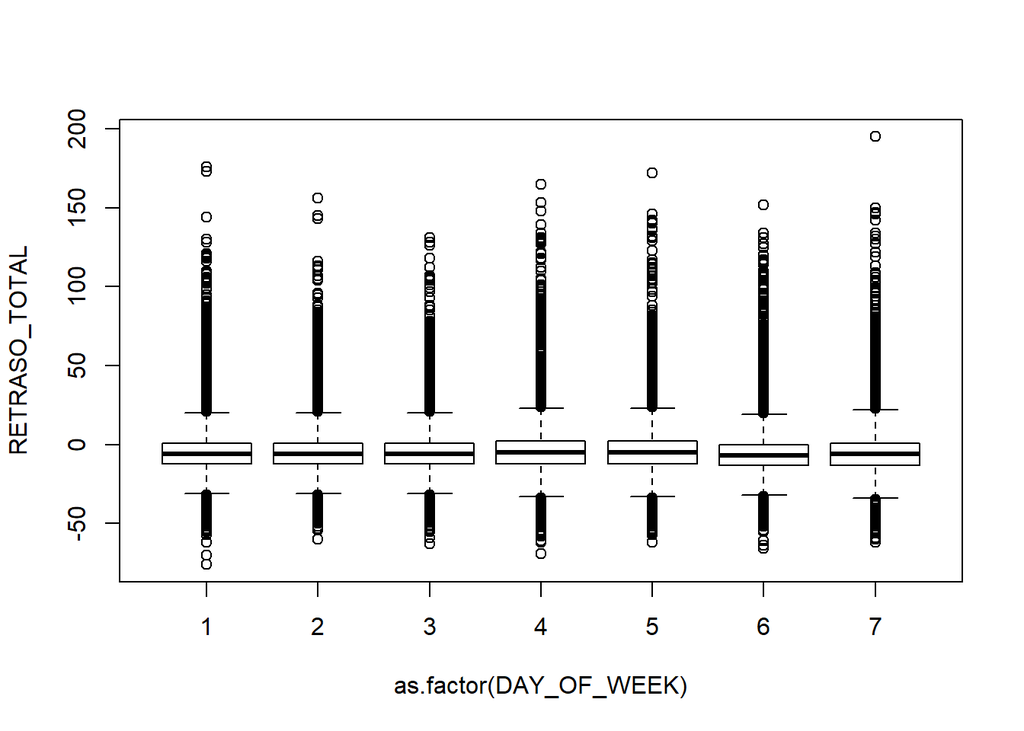

```r
plot(RETRASO_TOTAL ~ as.factor(DAY_OF_WEEK), data=vuelos_reduc)
```

Según el gráfico parece que podemos tener homogeneidad en las varianzas

```r
LeveneTest(RETRASO_TOTAL ~ as.factor(DAY_OF_WEEK), vuelos_reduc, center=median)
```

```
## Levene's Test for Homogeneity of Variance (center = median)
##           Df F value    Pr(>F)
## group      6  6.3417 1.099e-06 ***
##       285643
## ---
## Signif. codes:  0 '***' 0.001 '**' 0.01 '*' 0.05 '.' 0.1 ' ' 1
```

El Test de Levene nos da un p-valor de 1.099e-06 que es menor que 0.05 (95% de nivel de significación), con lo que rechazaríamos la hipotesis nula de varianzas iguales.

Comprobamos con el test de Filgner-Killeen, que habitualmente se utiliza si desconocemos si la distribución es normal o en el caso de que no se tenga una distribución normal de la varible.

```r
fligner.test(RETRASO_TOTAL ~ as.factor(DAY_OF_WEEK), data=vuelos_reduc)
```

```
##
##  Fligner-Killeen test of homogeneity of variances
##
## data:  RETRASO_TOTAL by as.factor(DAY_OF_WEEK)
## Fligner-Killeen:med chi-squared = 39.846, df = 6, p-value = 4.884e-07
```

Comprobamos con otras variables como el mes o la hora de salida.

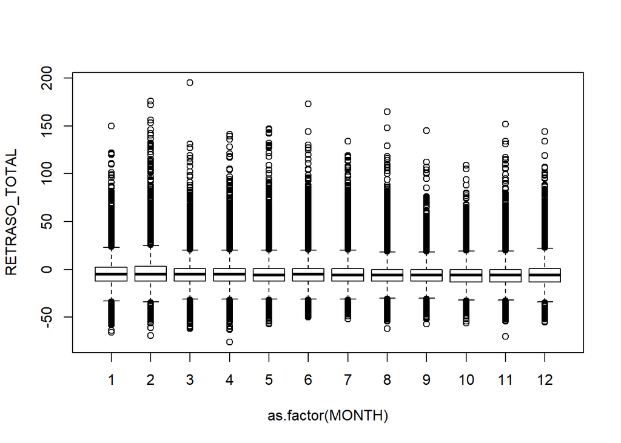

```r
plot(RETRASO_TOTAL ~ as.factor(MONTH), data=vuelos_reduc)
```

```r
LeveneTest(RETRASO_TOTAL ~ as.factor(MONTH), vuelos_reduc, center=mean)
```

```
## Levene's Test for Homogeneity of Variance (center = mean)
##           Df F value    Pr(>F)
## group     11  72.768 < 2.2e-16 ***
##       285638
## ---
## Signif. codes:  0 '***' 0.001 '**' 0.01 '*' 0.05 '.' 0.1 ' ' 1
```

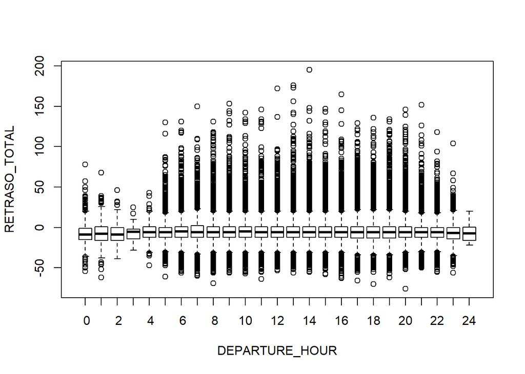

```r
plot(RETRASO_TOTAL ~ DEPARTURE_HOUR, data=vuelos_reduc)
```

En el caso de la hora de salida si que se aprecian ciertas diferencias los tramos horarios de madrugada, donde no hay apenas vuelos programados, por lo que el resultado esperado en este caso podría decirse que será la no homogeneidad de la varianza.

```r
LeveneTest(RETRASO_TOTAL ~ DEPARTURE_HOUR, vuelos_reduc, center=mean)
```

```
## Levene's Test for Homogeneity of Variance (center = mean)
##           Df F value    Pr(>F)
## group     24  24.353 < 2.2e-16 ***
##       285625
## ---
## Signif. codes:  0 '***' 0.001 '**' 0.01 '*' 0.05 '.' 0.1 ' ' 1
```

Comprobamos que el p-valor obtenido, como en los casos anteriores, nos hace rechazar la hipótesis nula de varianzas similares. Por lo que se determina que no hay homogeneidad en las variables.

Vemos si podemos conseguir una mejora de la normalidad y la homocedasticidad aplicando la transformación de Box-Cox

```r
bx_vuelos_reduc <- BoxCox(vuelos_reduc$RETRASO_TOTAL, lambda = BoxCoxLambda(vuelos_reduc$RETRASO_TOTAL))
```

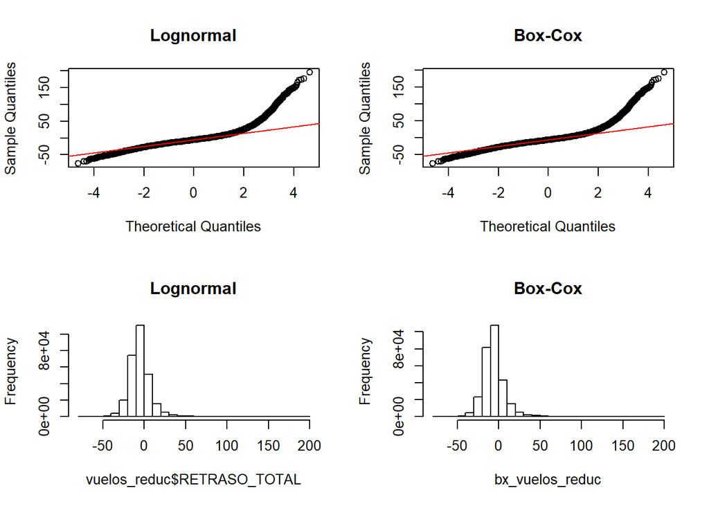

```r
par(mfrow=c(2,2))
qqnorm(vuelos_reduc$RETRASO_TOTAL, main="Lognormal")
qqline(vuelos_reduc$RETRASO_TOTAL,col=2)
qqnorm(bx_vuelos_reduc, main="Box-Cox")
qqline(bx_vuelos_reduc,col=2)
hist(vuelos_reduc$RETRASO_TOTAL,main="Lognormal")
hist(bx_vuelos_reduc, main="Box-Cox")
```

No parece que encontremos una mejora de los datos con la transformación de Box-Cox.

## 4.3 Aplicación de pruebas estadísticas>

**Aplicación de pruebas estadísticas para comparar los grupos de datos. En función de los datos y el objetivo del estudio, aplicar pruebas de contraste de hipótesis, correlaciones, regresiones, etc. Aplicar al menos tres métodos de análisis diferentes.**

Lo primero que vamos a hacer es comprobar la correlación entre algunas de las variables:

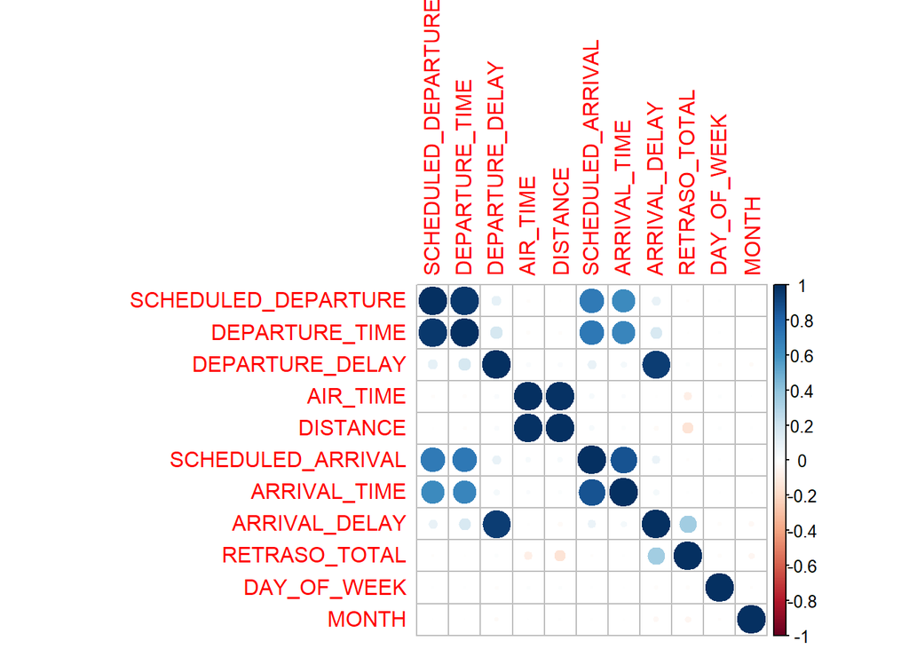

```r
correlacion <- dplyr::select(vuelos_reduc, "SCHEDULED_DEPARTURE", "DEPARTURE_TIME", "DEPARTURE_DELAY",
                      "AIR_TIME", "DISTANCE", "SCHEDULED_ARRIVAL", "ARRIVAL_TIME","ARRIVAL_DELAY",
                      "RETRASO_TOTAL","DAY_OF_WEEK","MONTH")

corr.res<-cor(correlacion)
corrplot(corr.res,method="circle")
```

Comprobamos una fuerte relación entre el retraso en la salida y el retraso en la llegada, que puee deberse a los vuelos no retrasados o quizá pueda ser, que al contrario de lo que podríamos pensar, el retraso en la salida no es recuperado en la llegada.  
También vemos una fuerte relación entre la distancia y el tiempo de vuelo, algo que era de esperar. Se tiene también una relación, aunque no tan fuerte entre el tiempo estimado de llegada y el tiempo real de llegada.

Nos preguntamos ahora por la relación entre el retraso/adelanto de un vuelo con la hora del día en la que se realiza Para ello usaremos un modelo de regresión, dado que la variable día de la semana es de tipo factor y además crearemos una nueva variable que nos indique si el vuelo se ha retrasado o no.  
Primero vamos a crear la tabla de contingencia y calcularemos la estimación Odds Ratio para ver la relación entre las variables Veremos si existe relación entre la variable dependiente, en nuestro caso si hay retraso o no y las variables explicativas.  
Dividimos la muestra:

```r
retraso <- data.frame (RETRASO=vuelos_reduc$RETRASO_TOTAL)
retraso$RETRASO <- ifelse (retraso$RETRASO>0, "SI", "NO")
retraso <- data.frame (retraso, WEEKEND=vuelos_reduc$DAY_OF_WEEK)
#Contamos como fin de semana los viernes, sábados y domingos
retraso$WEEKEND <- ifelse ((retraso$WEEKEND=="5" | retraso$WEEKEND=="6" | retraso$WEEKEND=="7"), "WEEKEND", "WEEKDAY")
str(retraso)
```

```
## 'data.frame':    285650 obs. of  2 variables:
##  $ RETRASO: chr  "SI" "NO" "NO" "NO" ...
##  $ WEEKEND: chr  "WEEKDAY" "WEEKDAY" "WEEKDAY" "WEEKDAY" ...
```

```r
table (retraso$RETRASO)
```

```
##
##     NO     SI
## 209810  75840
```

```r
tabla_retraso_dias <- with(retraso, table(retraso$RETRASO,retraso$WEEKEND))
tabla_retraso_dias %>% knitr::kable("html")  %>% kable_styling(position='center', font_size=12, fixed_thead=list(enabled=T))
```

|  | WEEKDAY | WEEKEND |
| --- | --- | --- |
| NO | 122977 | 86833 |
| SI | 45656 | 30184 |

Aplicamos la función chi-cuadrado de Pearson a las variables para conocer si podemos aceptar la hipótesis nula y por lo tanto las variables no están relacionadas.

```r
chisq.test(tabla_retraso_dias, correct=FALSE)
```

```
##
##  Pearson's Chi-squared test
##
## data:  tabla_retraso_dias
## X-squared = 58.006, df = 1, p-value = 2.613e-14
```

```r
library(epitools)
oddsratio(tabla_retraso_dias, verbose = TRUE)
```

```
## $x
##
##      WEEKDAY WEEKEND
##   NO  122977   86833
##   SI   45656   30184
##
## $data
##
##         WEEKDAY WEEKEND  Total
##   NO     122977   86833 209810
##   SI      45656   30184  75840
##   Total  168633  117017 285650
##
## $p.exposed
##
##           WEEKDAY   WEEKEND     Total
##   NO    0.7292582 0.7420546 0.7345003
##   SI    0.2707418 0.2579454 0.2654997
##   Total 1.0000000 1.0000000 1.0000000
##
## $p.outcome
##
##           WEEKDAY   WEEKEND Total
##   NO    0.5861351 0.4138649     1
##   SI    0.6020042 0.3979958     1
##   Total 0.5903483 0.4096517     1
##
## $measure
##     odds ratio with 95% C.I.
##       estimate     lower     upper
##   NO 1.0000000        NA        NA
##   SI 0.9362943 0.9205703 0.9522808
##
## $conf.level
## [1] 0.95
##
## $p.value
##     two-sided
##        midp.exact fisher.exact   chi.square
##   NO           NA           NA           NA
##   SI 2.475797e-14 2.518942e-14 2.612958e-14
##
## $correction
## [1] FALSE
##
## attr(,"method")
## [1] "median-unbiased estimate & mid-p exact CI"
```

```r
oddsratio(tabla_retraso_dias, rev="columns", verbose = TRUE)
```

```
## $x
##
##      WEEKEND WEEKDAY
##   NO   86833  122977
##   SI   30184   45656
##
## $data
##
##         WEEKEND WEEKDAY  Total
##   NO      86833  122977 209810
##   SI      30184   45656  75840
##   Total  117017  168633 285650
##
## $p.exposed
##
##           WEEKEND   WEEKDAY     Total
##   NO    0.7420546 0.7292582 0.7345003
##   SI    0.2579454 0.2707418 0.2654997
##   Total 1.0000000 1.0000000 1.0000000
##
## $p.outcome
##
##           WEEKEND   WEEKDAY Total
##   NO    0.4138649 0.5861351     1
##   SI    0.3979958 0.6020042     1
##   Total 0.4096517 0.5903483     1
##
## $measure
##     odds ratio with 95% C.I.
##      estimate   lower    upper
##   NO 1.000000      NA       NA
##   SI 1.068025 1.05011 1.086283
##
## $conf.level
## [1] 0.95
##
## $p.value
##     two-sided
##      midp.exact fisher.exact   chi.square
##   NO         NA           NA           NA
##   SI 2.4869e-14 2.518942e-14 2.612958e-14
##
## $correction
## [1] FALSE
##
## attr(,"method")
## [1] "median-unbiased estimate & mid-p exact CI"
```

El Odds Ratio nos indica que la razón entre la ocurrencia de retraso del vuelo frente a no retraso es 0,93 veces mayor en día laborable y de 1.068 veces superior en fin de semana. Identificamos que no es una diferencia muy pronunciada.